# MBTI

saleh fayyaz

May 2, 2018

```r
data = read_csv("mbti_1.csv")
types <- data.frame(type =data$type )
sentences = str_split_fixed(data$posts,"\\|\\|\\|",50)
type_sen = cbind(types,sentences)
### get list that each element is for one type
type_name <- types %>% distinct() %>% unlist()
type_list <- vector("list", 16)
names(type_list) <- type_name
for (i in 1:16){
  t<-  as.character(type_name[i])
  t_idx <- type_sen$type==t
  type_list[[t]]  <- c(as.matrix(type_sen[t_idx,-1]))
}

datatable(head(type_sen), style="bootstrap", class="table-condensed", options = list(dom = 'tp',scrollX = TRUE))
```

|  | type | 1 | 2 | 3 | 4 | 5 | 6 | 7 | 8 | 9 | 10 | 11 | 12 | 13 | 14 | 15 | 16 | 17 | 18 | 19 | 20 | 21 | 22 | 23 | 24 | 25 | 26 | 27 | 28 | … |
| --- | --- | --- | --- | --- | --- | --- | --- | --- | --- | --- | --- | --- | --- | --- | --- | --- | --- | --- | --- | --- | --- | --- | --- | --- | --- | --- | --- | --- | --- | --- |
| 1 | INFJ | 'http://www.youtube.com/watch?v=qsXHcwe3krw | http://41.media.tumblr.com/tumblr_lfouy03PMA1qa1rooo1_500.jpg | enfp and intj moments https://www.youtube.com/watch?v=iz7lE1g4XM4 sportscenter not top ten plays https://www.youtube.com/watch?v=uCdfze1etec pranks | What has been the most life-changing experience in your life? | http://www.youtube.com/watch?v=vXZeYwwRDw8 http://www.youtube.com/watch?v=u8ejam5DP3E On repeat for most of today. | May the PerC Experience immerse you. | The last thing my INFJ friend posted on his facebook before committing suicide the next day. Rest in peace~ http://vimeo.com/22842206 | Hello ENFJ7. Sorry to hear of your distress. It's only natural for a relationship to not be perfection all the time in every moment of existence. Try to figure the hard times as times of growth, as... | 84389 84390 http://wallpaperpassion.com/upload/23700/friendship-boy-and-girl-wallpaper.jpg http://assets.dornob.com/wp-content/uploads/2010/04/round-home-design.jpg ... | Welcome and stuff. | http://playeressence.com/wp-content/uploads/2013/08/RED-red-the-pokemon-master-32560474-450-338.jpg Game. Set. Match. | Prozac, wellbrutin, at least thirty minutes of moving your legs (and I don't mean moving them while sitting in your same desk chair), weed in moderation (maybe try edibles as a healthier alternative..… | Basically come up with three items you've determined that each type (or whichever types you want to do) would more than likely use, given each types' cognitive functions and whatnot, when left by... | All things in moderation. Sims is indeed a video game, and a good one at that. Note: a good one at that is somewhat subjective in that I am not completely promoting the death of any given Sim... | Dear ENFP: What were your favorite video games growing up and what are your now, current favorite video games? :cool: | https://www.youtube.com/watch?v=QyPqT8umzmY | It appears to be too late. :sad: | There's someone out there for everyone. | Wait... I thought confidence was a good thing. | I just cherish the time of solitude b/c i revel within my inner world more whereas most other time i'd be workin... just enjoy the me time while you can. Don't worry, people will always be around to..… | Yo entp ladies... if you're into a complimentary personality,well, hey. | ... when your main social outlet is xbox live conversations and even then you verbally fatigue quickly. | http://www.youtube.com/watch?v=gDhy7rdfm14 I really dig the part from 1:46 to 2:50 | http://www.youtube.com/watch?v=msqXffgh7b8 | Banned because this thread requires it of me. | Get high in backyard, roast and eat marshmellows in backyard while conversing over something intellectual, followed by massages and kisses. | http://www.youtube.com/watch?v=Mw7eoU3BMbE | http://www.youtube.com/watch?v=4V2uYORhQOk | … |
| 2 | ENTP | 'I'm finding the lack of me in these posts very alarming. | Sex can be boring if it's in the same position often. For example me and my girlfriend are currently in an environment where we have to creatively use cowgirl and missionary. There isn't enough... | Giving new meaning to 'Game' theory. | Hello *ENTP Grin* That's all it takes. Than we converse and they do most of the flirting while I acknowledge their presence and return their words with smooth wordplay and more cheeky grins. | This + Lack of Balance and Hand Eye Coordination. | Real IQ test I score 127. Internet IQ tests are funny. I score 140s or higher. Now, like the former responses of this thread I will mention that I don't believe in the IQ test. Before you banish... | You know you're an ENTP when you vanish from a site for a year and a half, return, and find people are still commenting on your posts and liking your ideas/thoughts. You know you're an ENTP when you..… | http://img188.imageshack.us/img188/6422/6020d1f9da6944a6b71bbe6.jpg | http://img.adultdvdtalk.com/813a0c6243814cab84c51 | I over think things sometimes. I go by the old Sherlock Holmes quote. Perhaps, when a man has special knowledge and special powers like my own, it rather encourages him to seek a complex... | cheshirewolf.tumblr.com So is I :D | 400,000+ post | Not really; I've never thought of E/I or J/P as real functions. I judge myself on what I use. I use Ne and Ti as my dominates. Fe for emotions and rarely Si. I also use Ni due to me strength... | You know though. That was ingenious. After saying it I really want to try it and see what happens with me playing a first person shooter in the back while we drive around. I want to see the look on... | out of all of them the rock paper one is the best. It makes me lol. You guys are lucky :D I'm really high up on the tumblr system. | So did you hear about that new first person shooter game? I've been rocking the hell out of the soundtrack on my auto sound equipment that will shake the heavens. We managed to put a couple PS3's in..… | No; The way he connected things was very Ne. Ne dominates are just as aware of their environments as Se dominates. Example: Shawn Spencer or Patrick Jane; Both ENTPs. | Well charlie I will be the first to admit I do get jealous like you do. I chalk it up to my 4w3 heart mixed with my dominate 7w8. 7s and 8s both like to be noticed. 4's like to be known (not the same.… | ;D I'll upload the same clip with the mic away from my mouth. Than you won't hear anything. Ninja Assassin style but with splatter. | Tik Tok is a really great song. As long as you can mental block out the singer. I love the beat it makes me bounce. | drop.io v1swck0 :D Mic really close to my mouth and smokin aces: assassins ball playing in the background. | Sociable =/= extrovert; I'm an extrovert and I'm not sociable. :) | Sherlock in the movie was an ENTP. Normally he's played as a EXTJ. In the books he's an ESTJ. As I said. The movie looked good except for it being called sherlock holmes. | http://i817.photobucket.com/albums/zz96/kamioo/Dirtywinch.png | Oh, I never had fear of kissing a guy. I will kiss an animal too. So there was nothing to vanish. Just personal taste and me not liking it. The guy I kissed didn't know me. It was one of those... | Sounds pretty much like my area and what I'm going through right now trying to figure out which way I want to take my life. I want to do so many things. The biggest problem is that I know if I don't..… | ;D I was operating under the impression that you were female. I never looked at your boxy. Okay, I help out my gay friends all the time and one of them has developed a little crush on me. I get red... | T_T You just described me and I'm living the worst nightmare. I'm trapped in one place with one one around. Only dull woods. If I was a serial killer this would be the perfect place but sadly I'm... | … |
| 3 | INTP | 'Good one _____ https://www.youtube.com/watch?v=fHiGbolFFGw | Of course, to which I say I know; that's my blessing and my curse. | Does being absolutely positive that you and your best friend could be an amazing couple count? If so, than yes. Or it's more I could be madly in love in case I reconciled my feelings (which at... | No, I didn't; thank you for a link! | So-called Ti-Si loop (and it can stem from any current topic/obsession) can be deadly. It's like when you're stuck in your own thoughts, and your mind just wanders in circles. Feels truly terrible. ..… | Have you noticed how peculiar vegetation can be? All you have to do is look down at the grass: dozens of different plant species there. And now imagine that hundreds of years later (when/if soil... | The Smiths – Never Had No One Ever | I often find myself spotting faces on marble tiles/wood. | This 5 year-old sentence is an incredibly accurate and beautiful description. | I haven't visited this website in the last 3 years. So whoever reads this (and maybe even remembers me, which I highly doubt): hi. 700049 700057 | When you sit in your garden until 10:30 PM writing songs, and sing them (together with dozens of crickets) while playing your acoustic guitar. | This is the most INTP-ish thread I've ever seen. | I wouldn't be able to look at the painting for the entire life if I knew that I picked it over the human being. | I was drawing a background for my animation on which I'm working right now - it should have been Mars.. But I felt obligated to make Mark Watneyx92s postcard from it :D If you read the book... | I started to make comics about turtle Gordon and unicorn Chimes - here you can see two first stories: https://www.tumblr.com/blog/-alexxxandra- | INTJ Recently I started to post my comics about two friends - turtle Gordon and unicorn Chimes. Before that, I just posted stuff that interested me, but from now on I'll try to include only my works..… | Probably we could work together on a new model - I'm an expert in abrupt explosions of laughter upon various weird stuff. That happens because of peculiar sense of humor - so peculiar that not much... | Hellooo Nah, you can touch it. Everyone thinks that it's scared or sad, but that's not true - in fact it has an absolutely neutral face. And this kitten actually really likes patting and hugs (only... | Well.. kind of; As it was already mentioned, sometimes because of Ni it's hard to convey complex stuff which pops up in your head in whimsical compilations of shapes and pictures only with words.... | I think this kitten would be very appropriate here. 376562 | 367034 | GOOD NIGHT everyone out there! Even if for someone there is morning right now - nights always supersede mornings.. And people say good night in order to meet next day :) | Oh, that movie :) It's awesome Thank you! Hope you had good sleep in the air; anyway, I'm wishing you good night for the next night ahead! (hopefully it will be on land) Good people deserve good... | 358882 358890 | Well, other people who may be wondering about an issue from the name of the topic will find your response helpful anyway :) | This. Finally someone mentioned that :) | I still see creatures/faces in a maze of various random patterns. It can be amusing sometimes. It's a very handy skill when you're bored. | Oh, I didn't know that.. What a pity. Why not sacrifice whole supermarket, then? We can decide which Walmart will be the best (I think the biggest one would be great). | … |
| 4 | INTJ | 'Dear INTP, I enjoyed our conversation the other day. Esoteric gabbing about the nature of the universe and the idea that every rule and social code being arbitrary constructs created... | Dear ENTJ sub, Long time no see. Sincerely, Alpha | None of them. All other types hurt in deep existential ways that I want no part of. | Probably a sliding scale that depends on individual preferences, like everything in humanity. | Draco Malfoy also. I'd say he's either 358 or 368. | I'm either 358 or 385, though in which stacking to me is a somewhat arbitrary distinction to make as I believe that the core indicates primary motivation and has a hand in every action. Therefore, a..… | I'm not particularly introverted or extraverted, personally. That said, I would say I'm somewhat unphased by either social interactions or being alone. What I'd say I crave more so than anything is... | Dear Type 9 INFP, Your absolute admiration of me is refreshing. You're a great girlfriend and I wish we both didn't have such busy schedules so we could be around one another more often. Keep... | 2% still means about 1/50 people. I've probably seen 1-2 others today. I never understood fascination by virtue of rarity. | So, you're on the ESFJ train also, right? | I have toyed with the idea of the OP being an extrovert also for awhile now, actually. After many conversations with him, however I'm disinclined to believe it due to OP being much too close with Fi..… | Still ESFJ | I disagree. Definite ESFJ. Fe- Si ALL up in this. | Where have you been? Your mother and I have been worried sick. | Similar feelings concerning ENTPs. | I collect shoes. I do so because I like status and nothing communicates such a thing as much as a pair of Jordans. | Sure. Let's get weird. Back. Off. | Best... | [Insert other into previous post.] | Wow, don't nobody got time fo' dat... Jk, u kno u mah boi. | Well, as I'm sure everyone knows, being social primary doesn't necessarily equal being social. I like other people just fine, but lately I've been on a bit of a break when it comes to my... | That's pretty crappy of her. Your sex life is definitely not her business. If I were you, I'd definitely talk to her about it. | Yeah, I had a lot longer to think about it. That said, I don't think you're Te, so if we operate under the assumptions in the OP, you're INFJ because nothing else makes sense. I'm not saying I... | Whether or not you actually are, your mom makes fun of you for being a virgin? Is this playful teasing? | Just stab in the dark here, I don't think that's Te under the hood. If this here is all I'm given to work with, I'd have to say INFJ. Compare your idea of 'logic' to mine: Logic is a series of... | What makes the most sense? | Tentatively INTJ. Still reading. EDIT: So far, I am of the belief that you're most of the things you say you are. I appreciate the level of detail. EDIT: Also relatively certain you are Ni... | Refreshing self with reading about instinctual variants. God, I'm a hard social type. | … |
| 5 | ENTJ | 'You're fired. | That's another silly misconception. That approaching is logically is going to be the key to unlocking whatever it is you think you are entitled to. Nobody wants to be approached with BS... | But guys... he REALLY wants to go on a super-duper-long-ass vacation. C'mon guys. His boss just doesn't listen or get it. He even approached him logically and everything. | Never mind. Just go on permanent vacation. | Two months? I wouldn't be crazy about the idea. If you are really his best employee, then that's what may be cooking him. Who wants their most reliable asset gone for that long? ENTJ employer... | Lol. Its not like our views were unsolicited. What a victim. | Sometimes I just really like impoverished rap music. https://www.youtube.com/watch?v=Xh0vA6_8mv8 | I probably would have lost it too. His stonewalling was insignificant. He was being an idiot over semantics that didn't have any impact on anything. It's one thing to stone wall on critical shit, but.… | I would have just taken the project and gave them something later. | The court deposition wasn't a skit. That actually happened. It was a verbatim reenactment. | And her ass. | I'll flirt a woman for a piece of candy at the grocery store. Of course. I use whatever I have at my disposal to get what I want in the most efficient manner possible. If that means flirting that... | http://youtu.be/PZbqAMEwtOE | Yes. In the comments she gave more info, then was shut down because she went from having a crush on her boss and wanted to know how to impress him, to her boss is married and she wasn't interested. I.… | What's this we thing about? | Callaendia are you the same INFP girl who was on the ENTJ Facebook forum with this similar question? I just have to ask because the times are so close together, and the scenario is so similar. | 3X | 11/25 I do not modify myself to suit others, however I do like the spotlight. | I think the easiest and most efficient approach is a tarp, jigsaw, and mulcher. But that's just my personal preference. Not all ENTJs are the same. | Just don't hump my leg... | What are you like a chihuahua or some shit? | I once dumped a girl in college who I was having a 6 month romp with over making me late for class. She said I was petty for it. | DEAD XD http://youtu.be/PaghIdSJKvQ | MBTIPC perfect. I don't like dealing with middle men either. You can talk directly to me. ;) | I can sell you the dream... | LOL DEAD. Ha! | The point is that when you are making a point of thinking critically but not thinking beyond common sense, you aren't using your brain. A little bit of effort now to have an understanding of the... | That's just common sense No, that's just a value judgement backed by popular opinion from social stupidity/laziness. That's only doing what works instead of pushing harder and doing what is... | … |
| 6 | INTJ | '18/37 @.@ | Science is not perfect. No scientist claims that it is, or that scientific information will not be revised as we discover new things. Rational thinking has been very useful to our society.... | INFP- Edgar Allen Poe was an INFP and he's in your siggy. | People see the obvious Fi and are quick to put her as INFP. I agree that she has no Ne. I see her as an ISFP. Compare her to Haku (definite INFP). She is flat through most of Naruto.. but I don't... | Lets get this party started 66314 | I did not say it disproved God. I merely said that I found such methods disturbing. Although, it does bring up certain questions. God is in control of the universe, and the governments of the world,..… | Surprisingly, I could not find a thread about this on perc even with Google. So, here you go. Watch Jesus Camp online - Watch Movies Online, Full Movies, Download I was disturbed watching this... | A metaphysical gun (Hell) held to someone's head can be just as effective as an actual gun. Do you not find these methods disturbing? Watch Jesus Camp online - Watch Movies Online, Full Movies,... | Unstable is not the right word. We are usually pretty emotionally flat-lined. But, when we do have to deal with our own emotions we can be very bad at it. In high school my feelings of attraction... | Well, I went to someone's wedding and dipped everything in the chocolate fountain and ate it. I dipped the fruit, the fish, and even the Hershey's kisses. And I drank two little jars of honey they... | That post you quoted was from two and a half years ago. Since then, I've come to a better explanation. INTPs may not be as externally certain as INTJs, but they are more certain internally. They... | This is how I deal with the INFP I'm in a relationship with. I am often tempted to avoid hurting them even if it means fudging the truth, telling them only what they want to hear. If I do that, it... | Never heard of it till now. I watch a loooot of anime, but I get it from animedreaming.tv mostly; I am not a member of any anime board. | The legs are nice, but her expression is all wrong. That is not her private sad face; I don't know what it is. See, I have her evil grin &lt;B | Kokiri Connect. Becuase I couldn't rememeber how to spell Kokoro Connect so I let Google do it. | Inaba from Kokoro Connect. Because I relate to her and I enjoy looking at her (I have to look at my avatar alot). | I'd like to see someone react when they are told they have hippopotomonstrosesquipedaliophobia. | She doesn't trust you or respect you. A break would be good to test if she will change. If she doesn't, you have to think about what will make you happy in the long term. Next time, establish ground..… | I don't think any INTJ is not going to do this if they have a choice. Though, until I got the internet in my late teens I didn't explore many subjects I was interested in in depth. Of course, it... | No, I don't smoke. I have an addictive personality, and I don't think I would be able to stop if I started. | Destroying his reputation by revealing what he has done could cause him to lose a lot of power... but if people knew things he had done, a certain person would kill him and end up in jail. There... | People like people like themselves; this is the number 1 indicator of attraction. Seeing as most people are sensors it is not surprising that they do not care for my personality. Woman have... | My best friend is an INTJ. We have so much in common even for two INTJs; she understands me better than anyone. It took a loooong time for us to become close. We put up a lot of barriers. I get... | I can tell you about a sociopath I know in real life. Not an INTJ, an ENTP or INTP. -Tells all his problems to people shortly after meeting them to attempt to gain their sympathy so they can be... | Light (at least in the beggning) and Lelouch did ultimately have good goals, even if their methods were evil. Lelouch did seem to feel remorse at times; a sociopath would never consider taking... | Nobody panics when things go according to plan. Even if the plan is horrifying. If tomorrow I tell the press that like a gang banger, will get shot, or a truckload of soldiers will be blown up,... | 1. Code Geass 2. Steins; Gate (It was hardest to pick between this and Geass, but I think Geass just barely beats it. I will say it is very slow in the beginning, but everything that happens in... | Looking back at this post from 2.5 years ago... Emil, Asahina, and Hinata are actually ISFPs. Maybe Kimmimaro and Alphonse as well. I really don't know Li Xingke's type... its been awhile since I... | … |

**count each type member ship**

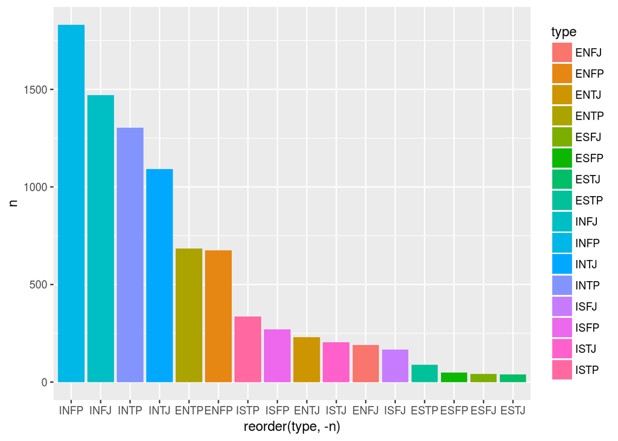

```r
type_count <-as.data.frame(count(types,type)) %>% arrange(n)
ggplot() + geom_bar(data = type_count,aes(x=reorder(type,-n),y=n,fill=type),stat='identity')
```

as we can see there are less Extroverted people(E type) in the net to find friends .

**count for each class**

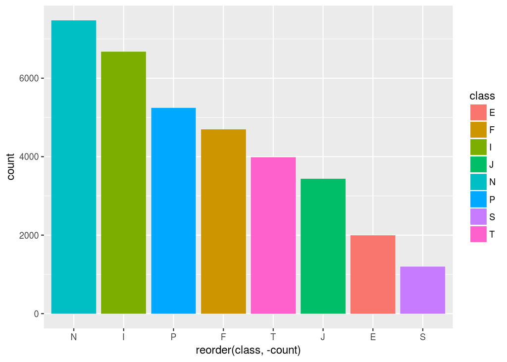

```r
diff_class <- str_split("IESNTFJP",'') %>% unlist()
type_mat <- matrix(nrow = dim(data)[1], ncol = 8)
colnames(type_mat) <- diff_class
for (i in 1:length(diff_class)){
  type_mat[,diff_class[i]] <- apply(types,1,function(x) return(ifelse(grepl(diff_class[i],x),1,0)))
}

diff_class_count <-apply(type_mat,2,sum)
diff_class_count <- data.frame(class = names(diff_class_count) , count = diff_class_count)
ggplot() + geom_bar(data = diff_class_count,aes(x=reorder(class,-count),y=count,fill=class),stat='identity')
```

we can see that we have more *intution* and *introvert* in our data than others. if this polpulation have same density as net have we can say we have more introverts and **comment length** now I want to find distributioan of *comment length* for each group: as we have some out liers that gives us bad plot i remove out liers .

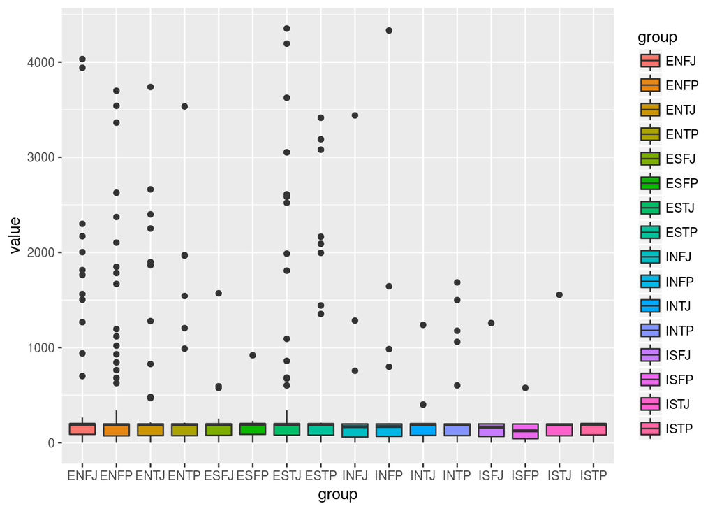

```r
type_sen_len <- data.frame()
for (i in 1:16){
  temp <- data.frame(group=type_name[i],value = str_count(type_list[[type_name[i]]]) )
  type_sen_len <- rbind(type_sen_len,temp)
  }

# create boxplot that includes outliers
p0 = ggplot(type_sen_len, aes(y = value)) + geom_boxplot(aes(x = group,fill=group))
p0
```

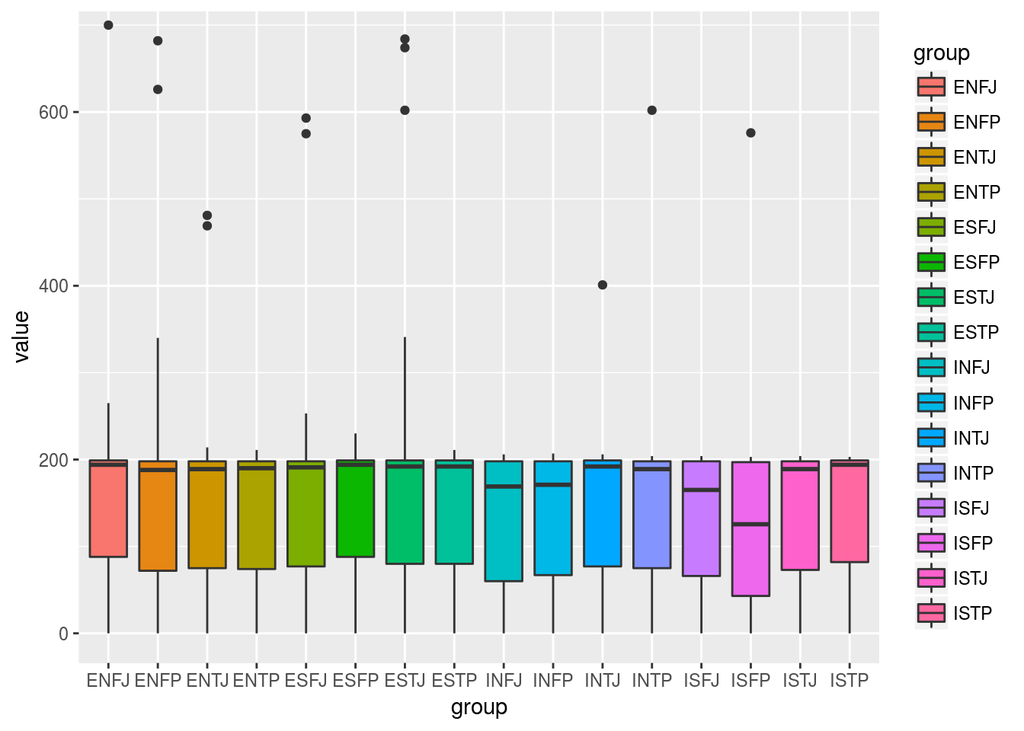

```r
# compute lower and upper whiskers
ylim1 = boxplot.stats(type_sen_len$value)$stats[c(1, 5)]

# scale y limits based on ylim1
p1 = p0 + coord_cartesian(ylim = ylim1*2)
p1
```

this plot doesnt show any thing good so i find diffrnce between each type sepratly : *Introversion (I) – Extroversion (E)*

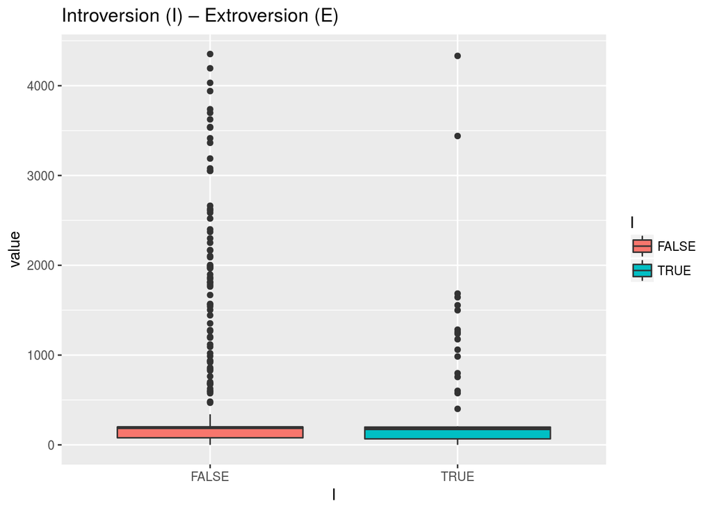

```r
for (i in 1:length(diff_class)){
type_sen_len[diff_class[i]] <- str_detect(type_sen_len$group,diff_class[i])
}

# create boxplot that includes outliers
p2 = ggplot(type_sen_len, aes(y = value)) + geom_boxplot(aes(x = I,fill=I)) +ggtitle('Introversion (I) – Extroversion (E)')
p2
```

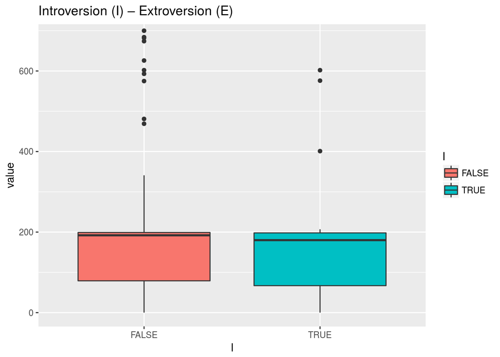

```r
# compute lower and upper whiskers
ylim1 = boxplot.stats(type_sen_len$value)$stats[c(1, 5)]

# scale y limits based on ylim1
p1 = p2 + coord_cartesian(ylim = ylim1*2)
p1
```

```r
t.test(value~I,data = type_sen_len ,alternative = "less")
```

```
##
##  Welch Two Sample t-test
##
## data:  value by I
## t = 19.897, df = 79425, p-value = 1
## alternative hypothesis: true difference in means is less than 0
## 95 percent confidence interval:
##      -Inf 7.247595
## sample estimates:
## mean in group FALSE  mean in group TRUE
##            142.7669            136.0727
```

**tokenization** We break the text into individual tokens which are simply individual words.

```r
all_type_sen <- data.frame()
for (i in 1:16){
  temp <- data.frame(group=type_name[i],text = type_list[[type_name[i]]])
  all_type_sen <- rbind(all_type_sen,temp)
}

all_type_sen[,2] <- sapply(all_type_sen[,2], as.character)

all_type_sen %>% unnest_tokens(word,text) -> all_type_words
all_type_words %>% head(10)
```

```
##     group    word
## 1    INFJ    they
## 1.1  INFJ   paint
## 1.2  INFJ without
## 1.3  INFJ numbers
## 2    INFJ    true
## 2.1  INFJ   sadly
## 2.2  INFJ     not
## 2.3  INFJ    many
## 2.4  INFJ    have
## 2.5  INFJ    felt
```

** 10 most commen words in all types ** i first filter *stop words* , *numbers* and *punct*to find real words in commen .

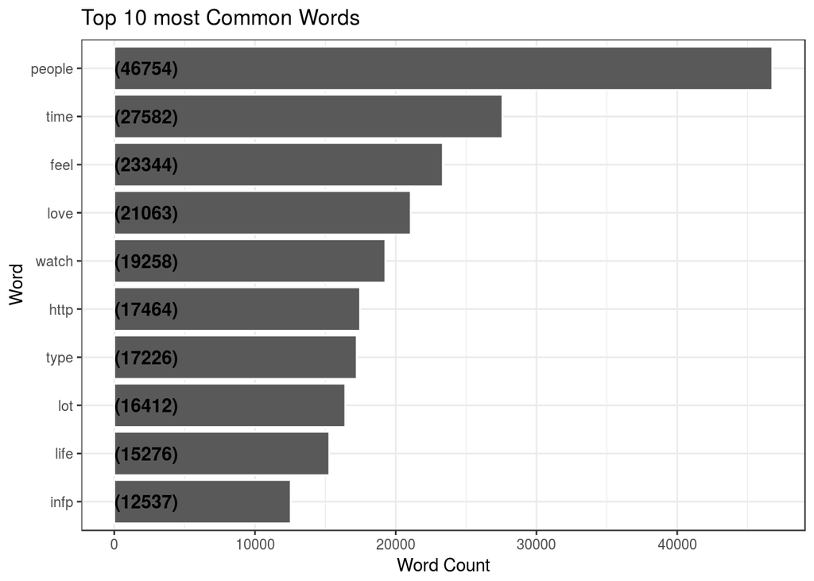

```r
createBarPlotCommonWords = function(data,title)
{
  data %>%
  filter(!word %in% stop_words$word) %>%
  count(word,sort = TRUE) %>%
  ungroup() %>%
  mutate(word = factor(word, levels = rev(unique(word)))) %>%
  head(10) %>%

  ggplot(aes(x = word,y = n)) +
  geom_bar(stat='identity',colour="white") +
  geom_text(aes(x = word, y = 1, label = paste0("(",n,")",sep="")),
            hjust=0, vjust=.5, size = 4, colour = 'black',
            fontface = 'bold') +
  labs(x = 'Word', y = 'Word Count',
       title = title) +
  coord_flip() +
  theme_bw()

}

all_type_words <- all_type_words[!str_detect(all_type_words$word,"[:digit:]"),]
all_type_words <-  all_type_words[!str_detect(all_type_words$word,"[:punct:]"),]
createBarPlotCommonWords(all_type_words,'Top 10 most Common Words')
```

it can be seen that words such as *people* and *time* and *love* has more frequency . **WordCloud of the Common Words**

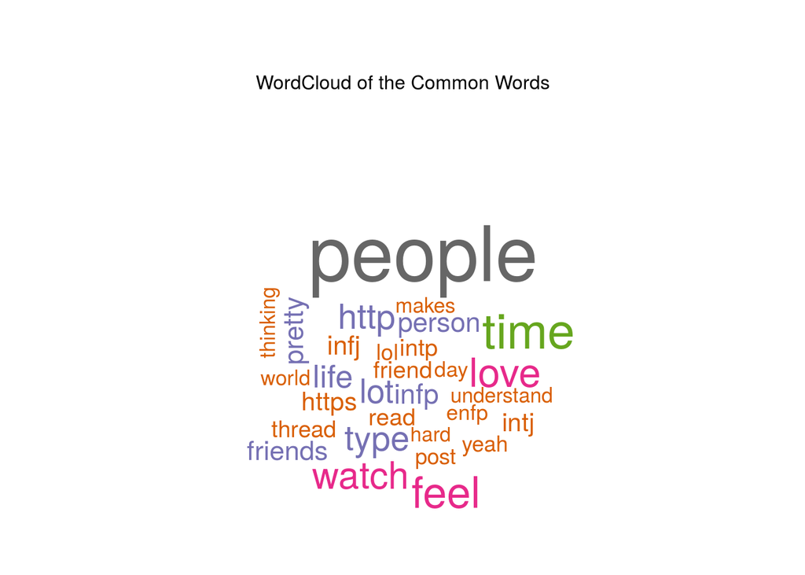

```r
createWordCloud = function(data,tit)
{

  layout(matrix(c(1, 2), nrow=2), heights=c(2, 5))
  par(mar=rep(0, 4))
  plot.new()

  text(x=0.5, y=0.5, tit )
  data %>%
  filter(!word %in% stop_words$word) %>%
  count(word,sort = TRUE) %>%
  ungroup()  %>%
  head(30) %>%
  with(wordcloud(word, n, max.words = 30,colors=brewer.pal(8, "Dark2")))
}

createWordCloud(all_type_words,'WordCloud of the Common Words')
```

** WORD CLOUD OF ALL 16 types**

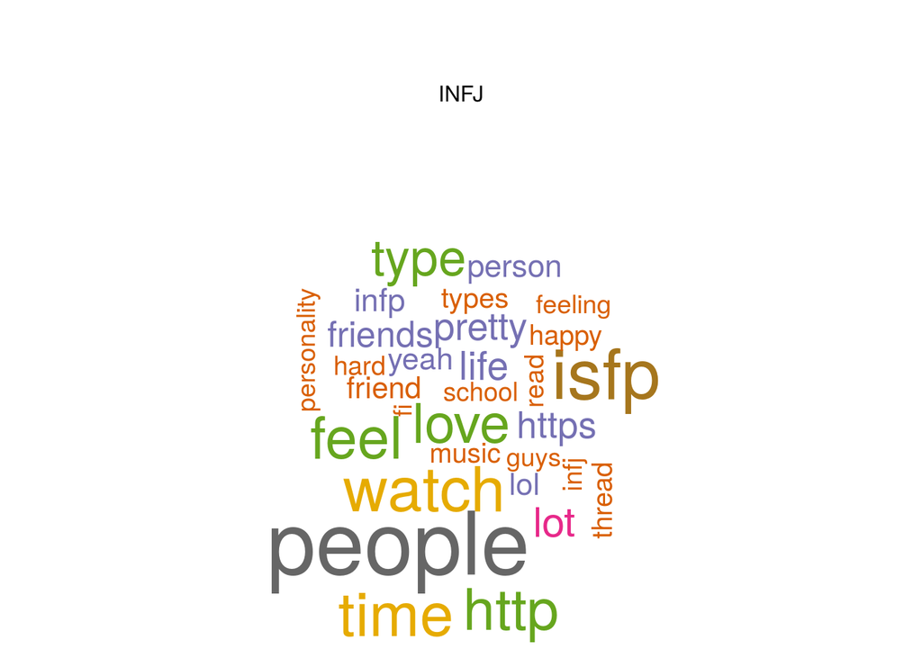

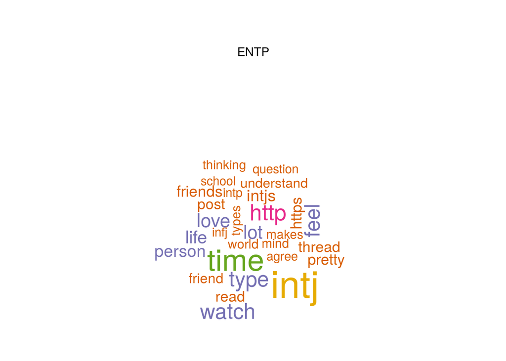

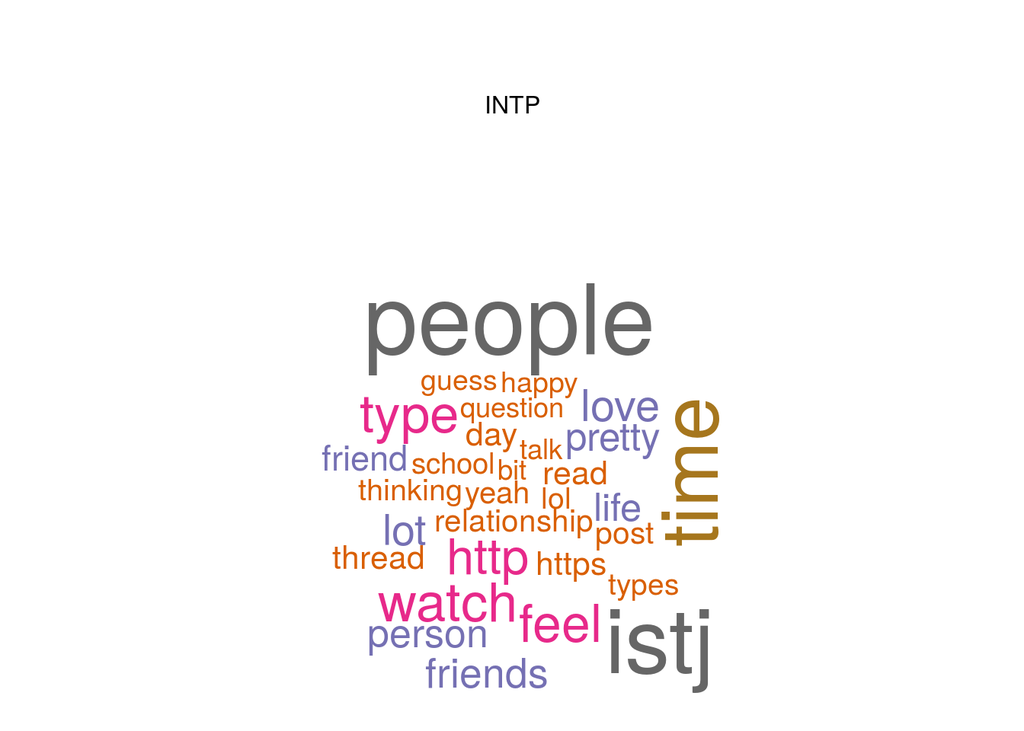

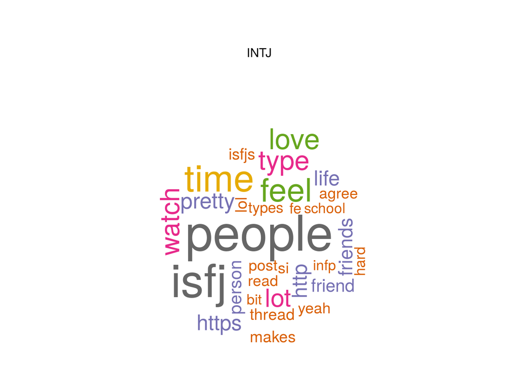

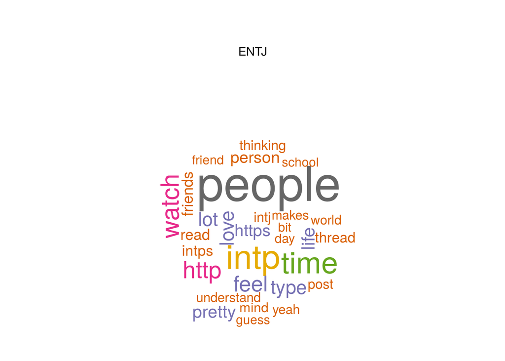

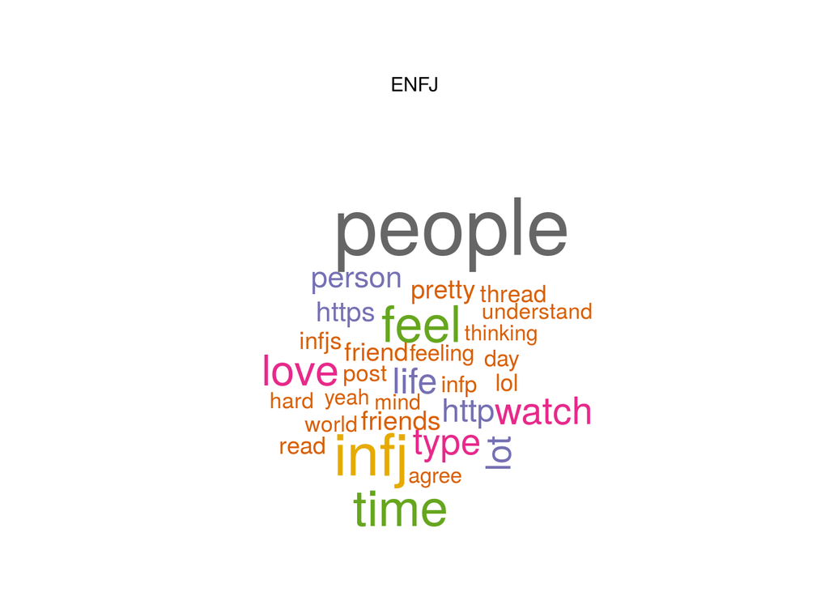

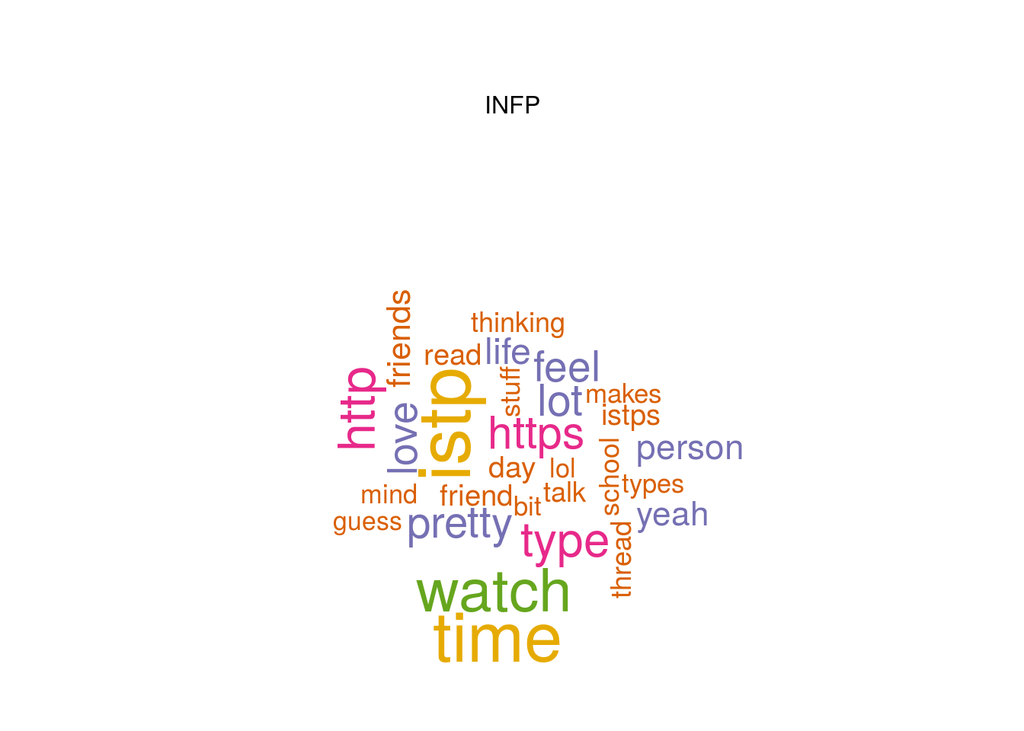

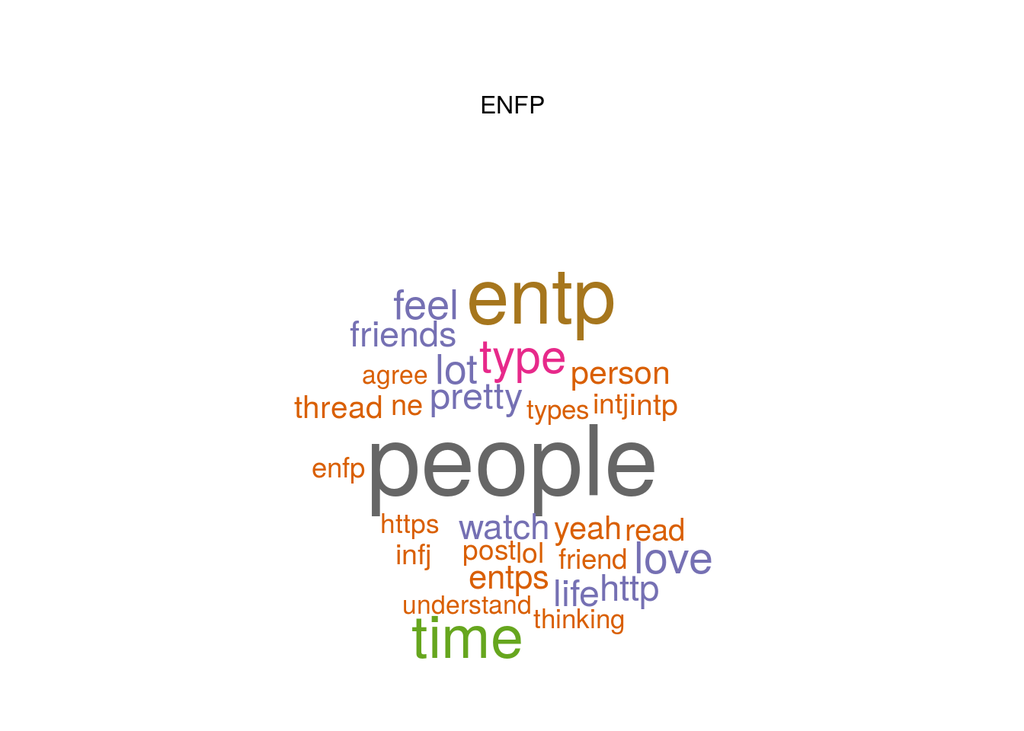

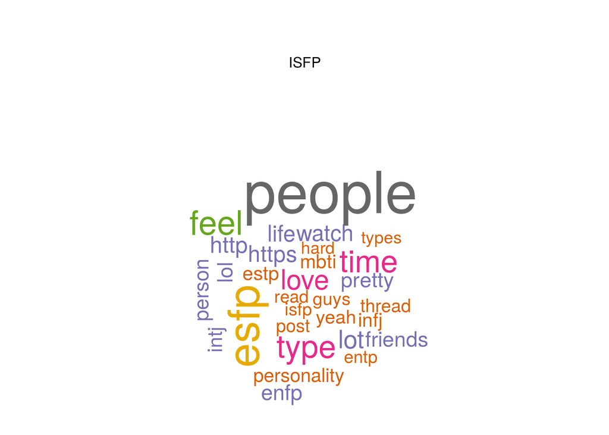

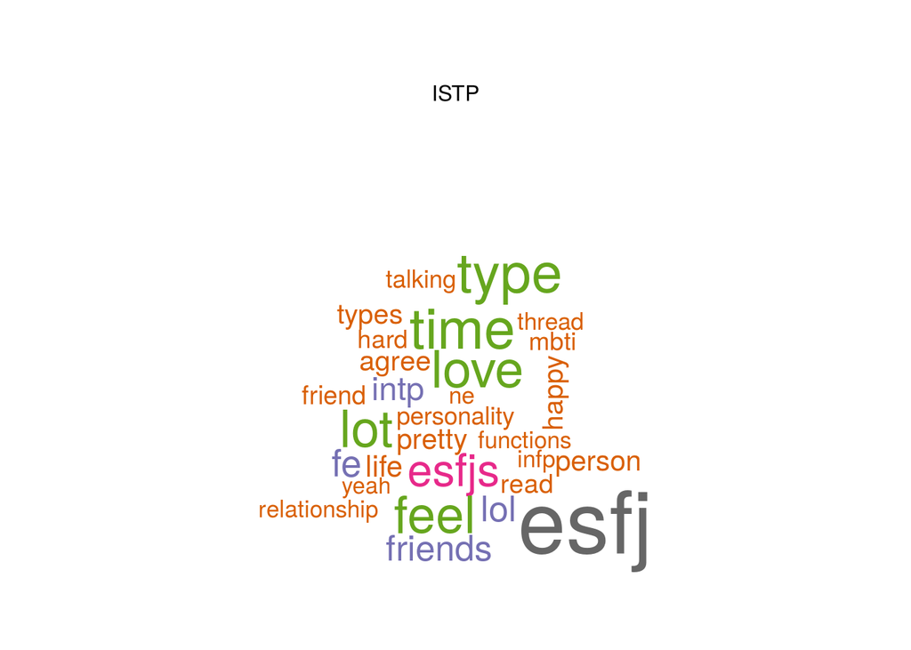

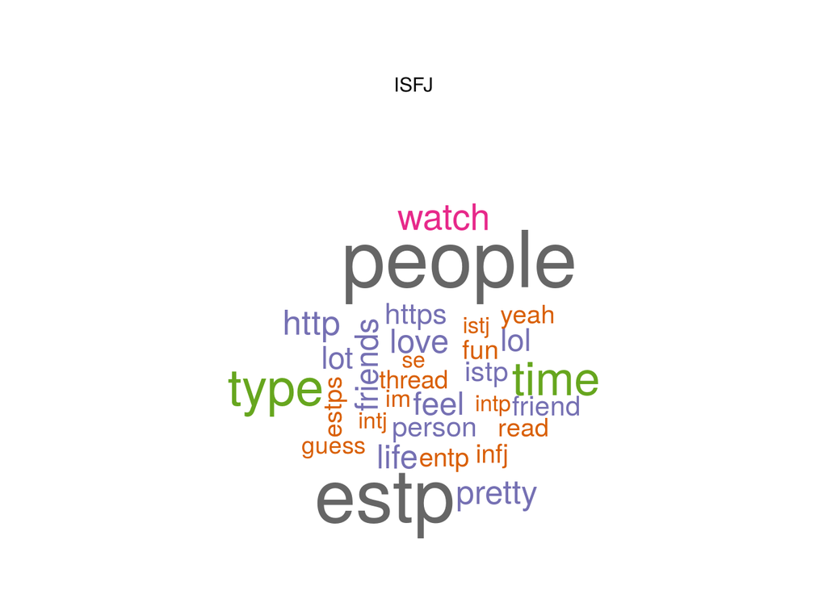

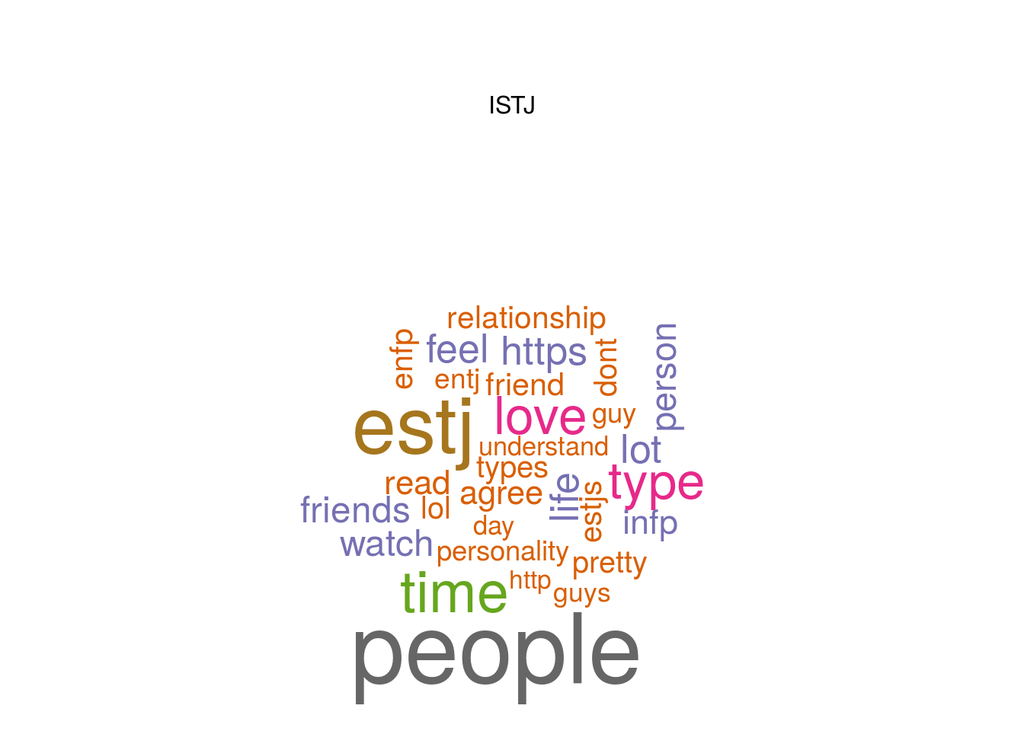

[4 more figures not shown]

```r
for (i in 1:16){
  createWordCloud(all_type_words %>% filter(group == type_name[i]),type_name[i])
}
```

for distingushing between *interovets*

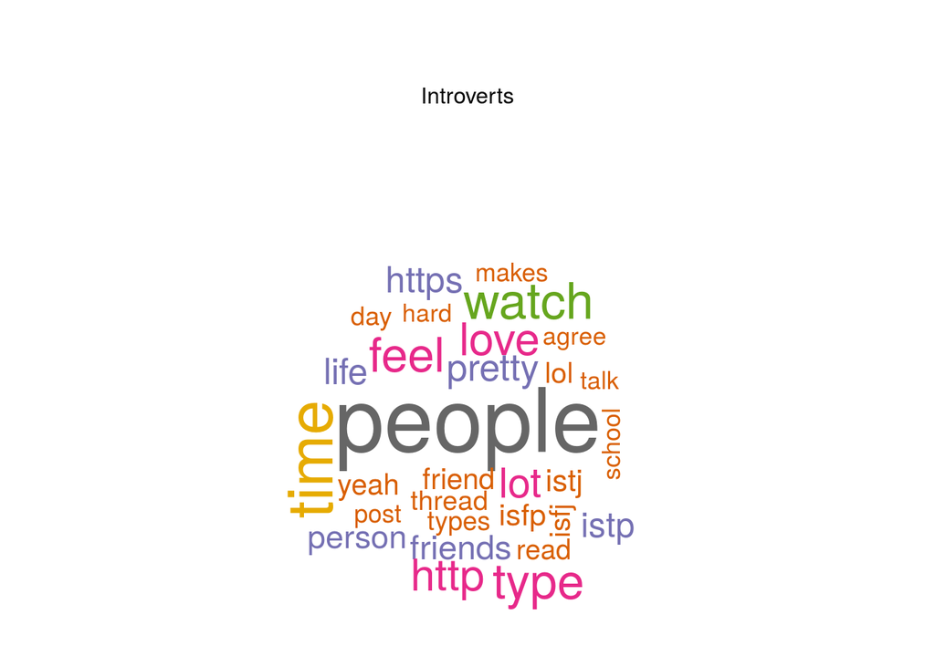

```r
  createWordCloud(all_type_words %>% filter(str_detect(group,'I')),"Introverts")
```

and *Extroverts*:

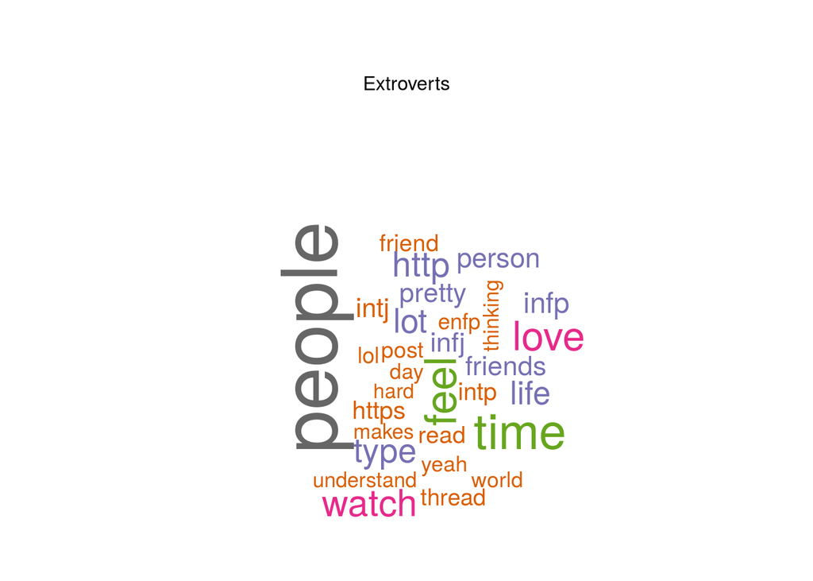

```r
  createWordCloud(all_type_words %>% filter(str_detect(group,'E')),"Extroverts")
```

that shows they almost use same words . for distigush between *Thinking* and *Feeling* people we got : *Thinking*

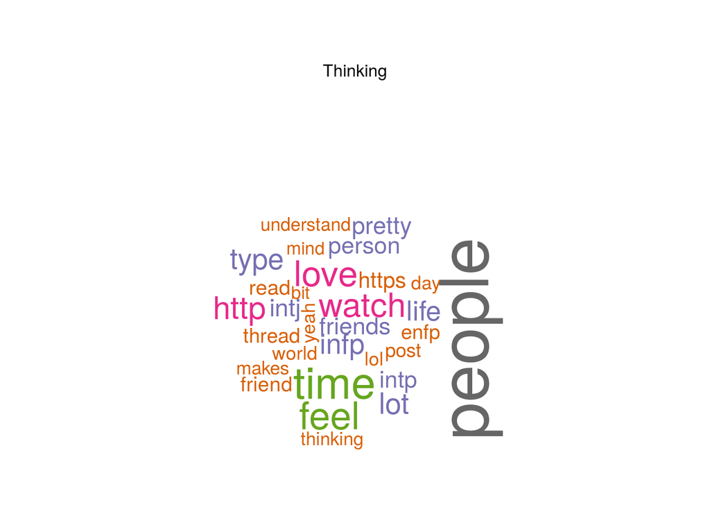

```r
  createWordCloud(all_type_words %>% filter(str_detect(group,'T')),"Thinking")
```

*feeling*

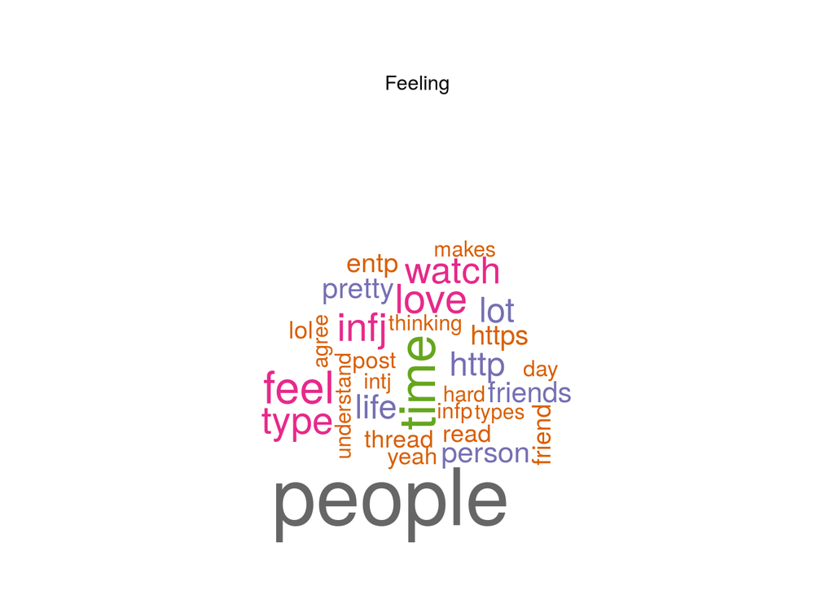

```r
  createWordCloud(all_type_words %>% filter(str_detect(group,'F')),"Feeling")
```

it seems that feeling people use *LOVE* and *feel* more than thinking people that using words such as *mind* more .